# Notes

[output not shown]

[output not shown]

# The problem

What is the unknown?

- 5 days of year of 2024 that correspond to the bloom dates for cherry blossoms for 5 different locations:
  - Washington DC, Liestal, Kyoto, Vancouver, and NYC
- Prediction intervals for these 5 days

What are conditions

- csv file for prediction
- Narrative (Quarto file)
- git repo

What are data?

Available

- for the five main sites:
  - All except NYC: a csv file with, location, long, lat, altitude, year of observation, bloom date and bloom doy.
- Other locations
  - Switzerland
  - Japan
  - South korea
  - USA (?) -> need to clean

Need to look for

- NYC
- Weather (temp) data for these locations

## Data so far

Quick look into 4 locations

```r
df <- read.csv("data/washingtondc.csv") %>%
  bind_rows(read.csv("data/liestal.csv")) %>%
  bind_rows(read.csv("data/kyoto.csv")) %>%
  bind_rows(read.csv("data/vancouver.csv")) %>%
  as.data.frame()
```

Some quick summary about locations

```r
location = c("Kyoto", "Liestal", "DC", "Vancouver", "NYC")
lat = c(35, 47, 39, 49, 41)
long = c(136, 8, -77, -123, -74)
alt = c(44, 350, 0, 24, 8.5)

table = cbind (location, lat, long, alt)

knitr::kable(table) %>%
  kable_styling()
```

| location | lat | long | alt |
| --- | --- | --- | --- |
| Kyoto | 35 | 136 | 44 |
| Liestal | 47 | 8 | 350 |
| DC | 39 | -77 | 0 |
| Vancouver | 49 | -123 | 24 |
| NYC | 41 | -74 | 8.5 |

By location

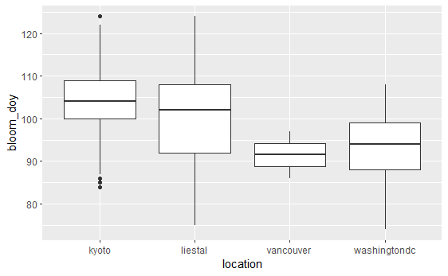

```r
ggplot(df, aes(y = bloom_doy, x = location))+
  geom_boxplot()
```

```r
NA
NA
```

Over the years

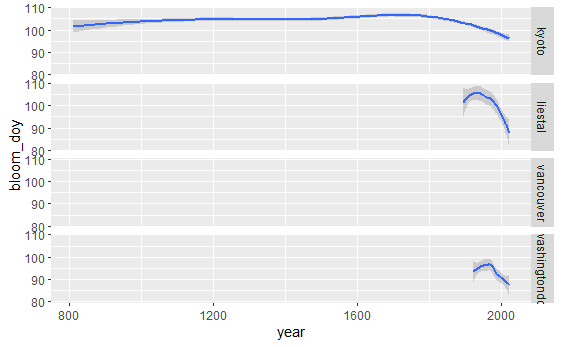

Decline over recent years…

is it normally distributed?

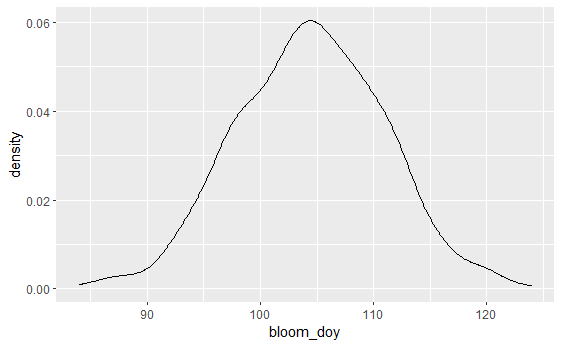

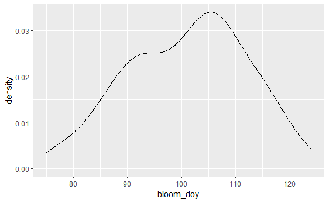

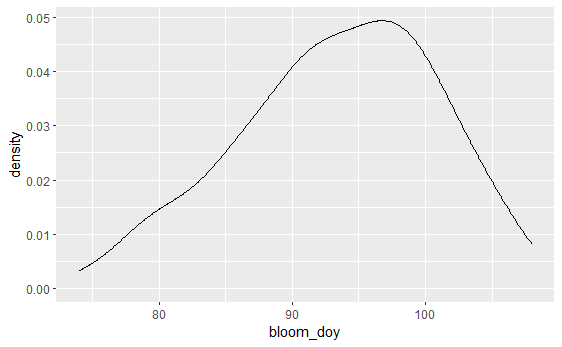

Perhaps can use normal regression for simplicity. Heavier tails for places witho only recent data most likely due to warming. Likely that distribution can be treated as normal given temperature

- Should be IID given one years bloom should not affect next years bloom
- predictors would be temperature
- Hierarchical gouped by location.
  - Or maybe use as predictors instead given we have empty data sets of NY and Vancouver… Lat, long and altitude need to be taken into consideration.

# getting temperature data

Lets first look at kyoto

```r
temp_kyoto <-
  ghcnd_search(stationid = "JA000047759",
               var = c("tmax", "tmin"),
               date_min = "1946-01-01",
               date_max = "2024-02-16") %>%
  reduce(left_join) %>%
  mutate(tmax = na.approx(tmax))%>%
  mutate(tmin = c(na.approx(tmin),4.8,4.8))%>%
  transmute(year = parse_number(format(date, "%Y")),
            date,
            tmax = tmax / 10,
            tmin = tmin / 10,
            temp = (tmax + tmin) / 2)
```

```
using cached file: C:\Users\yuche\AppData\Local/R/cache/R/rnoaa/noaa_ghcnd/JA000047759.dly
date created (size, mb): 2024-02-19 19:43:17 (1.711)
file min/max dates: 1945-10-01 / 2024-02-29
```

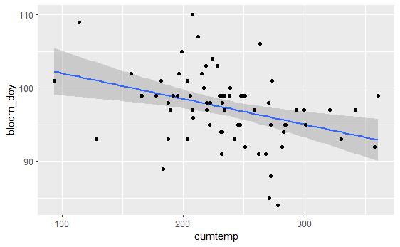

```r
kyoto = filter(df, year >= 1951, location == "kyoto")

get_temp_day = function(x, temps){
  temp_year = filter(temps, year == x)
  temp_year_wide = pivot_wider(temp_year[1:50,-1],  names_from = date, values_from = c(tmax, tmin, temp))
  temp_year_wide = as.data.frame(temp_year_wide)

  return((temp_year_wide))
}

years = kyoto$year

temps_list = lapply(years, get_temp_day, temps = temp_kyoto)
temps_df = as.data.frame(matrix(unlist(temps_list), nrow = 73, ncol =150, byrow= TRUE))
names(temps_df)= c(paste0("tmax", 1:50), paste0("tmin", 1:50), paste0("temp", 1:50))

kyoto = cbind(kyoto, temps_df)

kyoto = mutate(kyoto, cumtemp = rowSums(kyoto[,108:157]))

ggplot(kyoto, aes(x = cumtemp, y=bloom_doy))+
  geom_smooth(method = "lm")+
  geom_point()
```

Correlation appears to be light based on solely cumulative temperature…

```r
cor(kyoto$bloom_doy[-55], kyoto$cumtemp[-55],method = "pearson")
```

```
[1] -0.3661998
```

For middle temperature

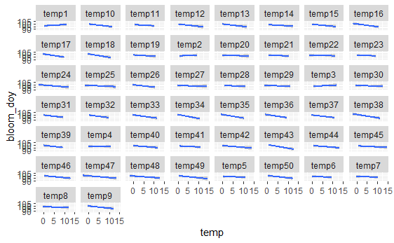

For lowest temperature

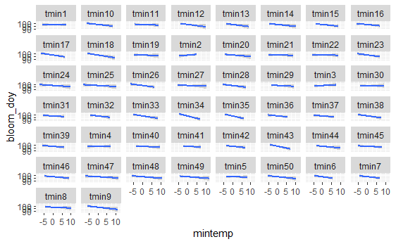

```r
kyoto_longer_2 = pivot_longer(kyoto, cols = c(58:107), names_to = "day", values_to = "mintemp")

ggplot(kyoto_longer_2, aes(x = mintemp, y=bloom_doy))+
  geom_smooth(method = "lm")+
  facet_wrap("day")
```

maximum temp:

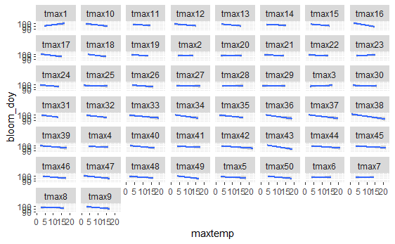

```r
kyoto_longer_3 = pivot_longer(kyoto, cols = c(8:57), names_to = "day", values_to = "maxtemp")

ggplot(kyoto_longer_3, aes(x = maxtemp, y=bloom_doy))+
  geom_smooth(method = "lm")+
  facet_wrap("day")
```

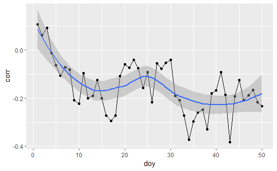

Seems like there is a weird trend where the correleation goes, down, up then down again…

See if repeateable for liestal and dc:

DC:

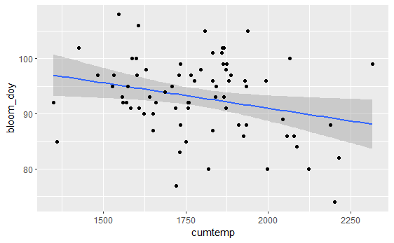

Correlation appears to be light based on solely cumulative temperature…

```r
cor(DC$bloom_doy[-c(1,55)], DC$cumtemp[-c(1,55)],method = "pearson")
```

```
[1] -0.2641276
```

For middle temperature

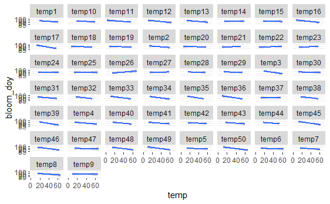

```r
DC_longer = pivot_longer(DC[-1,], cols = c(108:157), names_to = "day", values_to = "temp")

ggplot(DC_longer, aes(x = temp, y=bloom_doy))+
  geom_smooth(method = "lm")+
  facet_wrap("day")
```

For lowest temperature

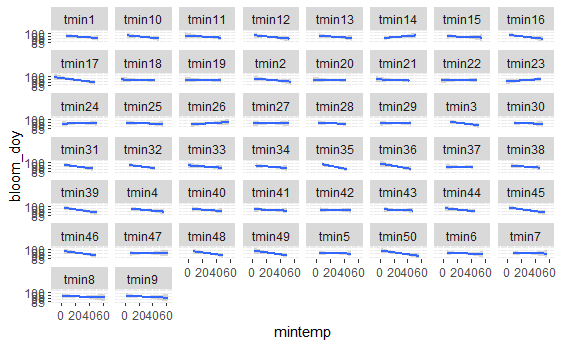

```r
DC_longer_2 = pivot_longer(DC[-1,], cols = c(58:107), names_to = "day", values_to = "mintemp")

ggplot(DC_longer_2, aes(x = mintemp, y=bloom_doy))+
  geom_smooth(method = "lm")+
  facet_wrap("day")
```

maximum temp:

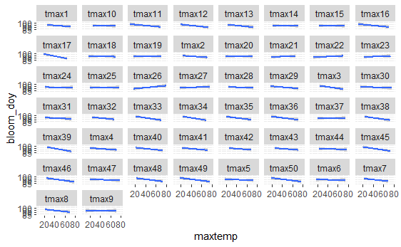

```r
DC_longer_3 = pivot_longer(DC[-1,], cols = c(8:57), names_to = "day", values_to = "maxtemp")

ggplot(DC_longer_3, aes(x = maxtemp, y=bloom_doy))+
  geom_smooth(method = "lm")+
  facet_wrap("day")
```

```r
DC_remove_na = DC[-c(1,55),]
corr = lapply(DC_remove_na[,108:157], cor, y = DC_remove_na$bloom_doy)

corr = unlist(corr)

corr = as.data.frame(cbind(corr, 1:50))
names(corr) = c("corr", "doy")

ggplot(corr, aes (x = doy, y = corr))+
  geom_point()+
  geom_line()+
  geom_smooth()
```

[output not shown]

# Build model

Step 1 clean data

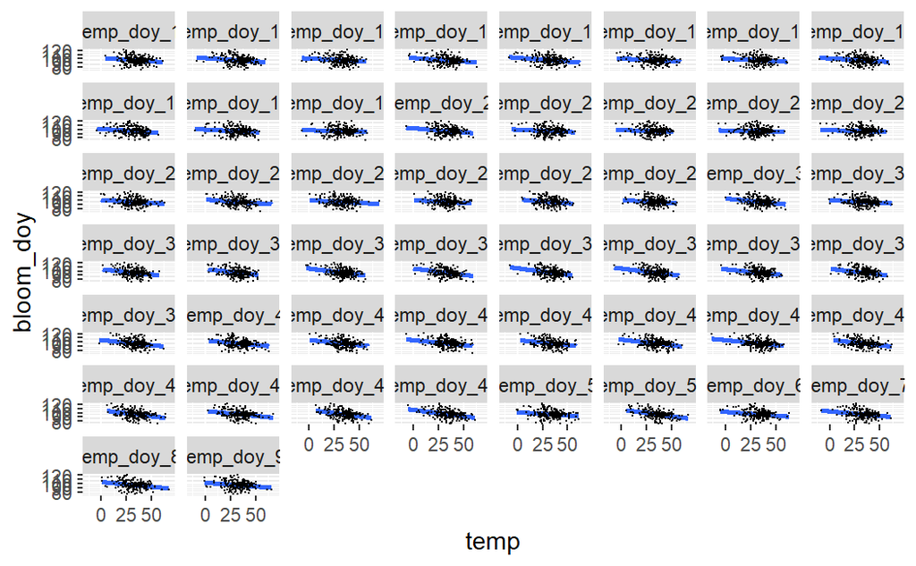

```r
temp = read.csv("./data/weather.csv")

# function to arrange temp data into dataframe by year from day 1:50
get_temp_day = function(x, temps){
  temp_year = filter(temps, year == x)
  temp_year_wide = pivot_wider(temp_year[1:50,-1],  names_from = date, values_from = temp)
  temp_year_wide = as.data.frame(temp_year_wide)

  return((temp_year_wide))
}

# function to patch together temp data with bloom data
combine_temp_data = function(stationid, loc, tavg = FALSE){

  if(tavg == FALSE){
  temp_data = filter(temp, STATION == stationid)%>%
  mutate(DATE = as.Date(DATE, format = "%d/%m/%Y"),
         TMAX = na.approx(TMAX),
         TMIN = na.approx(TMIN))%>%
  transmute(year = parse_number(format(DATE, "%Y")),
            date = DATE,
            temp = (TMAX + TMIN) / 2)
  }else{temp_data = filter(temp, STATION == stationid)%>%
  mutate(DATE = as.Date(DATE, format = "%d/%m/%Y"),
         TAVG = na.approx(TAVG))%>%
  transmute(year = parse_number(format(DATE, "%Y")),
            date = DATE,
            temp = TAVG)}

station = filter(df, year >= temp_data$year[1], location == loc)


years = station$year

temps_list = lapply(years, get_temp_day, temps = temp_data)
temps_df = as.data.frame(matrix(unlist(temps_list), nrow = length(temps_list), ncol =50, byrow= TRUE))
names(temps_df)= c(paste0("temp_doy_", 1:50))

bloom_temp = cbind(station, temps_df)
return(bloom_temp)
}


vancouver = combine_temp_data(stationid = "CA001108395", loc = "vancouver", tavg = TRUE)
dc = combine_temp_data(stationid = "USC00186350", loc = "washingtondc")
kyoto = combine_temp_data(stationid = "JA000047759", loc = "kyoto")
liestal = combine_temp_data(stationid = "Liestal", loc = "liestal", tavg = TRUE)

df_combined = na.omit(rbind (vancouver, dc, kyoto, liestal))


df_combined_longer = pivot_longer(df_combined[-1,], cols = c(8:57), names_to = "day", values_to = "temp")

ggplot(df_combined_longer, aes(x = temp, y=bloom_doy))+
  geom_smooth(method = "lm")+
  geom_point(size = 0.1)+
  facet_wrap("day")
```

correlations

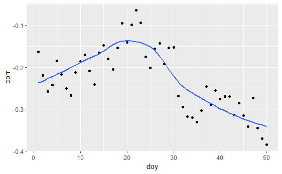

# Build the model

## specifiying the model

predictors will be location and temperature of each bloom doy

we use a weakly informative prior:

sd and mean of each bloom doy by location:

```r
summary =
  df_combined %>%
  group_by(location)%>%
  summary()
print(summary)
```

[output not shown]

[figure not shown]

model:

```r
model = stan_glm(
  bloom_doy ~ location + temp_doy_1 + temp_doy_2 + temp_doy_3 + temp_doy_4 + temp_doy_5 + temp_doy_6 + temp_doy_7 + temp_doy_8 + temp_doy_9 + temp_doy_10 + temp_doy_11 + temp_doy_12 + temp_doy_13 + temp_doy_14 + temp_doy_15 + temp_doy_16 + temp_doy_17 + temp_doy_18 + temp_doy_19 + temp_doy_20 + temp_doy_21 + temp_doy_22 + temp_doy_23 + temp_doy_24 + temp_doy_25 + temp_doy_26 + temp_doy_27 + temp_doy_28 + temp_doy_29 + temp_doy_30 + temp_doy_31 + temp_doy_32 + temp_doy_33 + temp_doy_34 + temp_doy_35 + temp_doy_36 + temp_doy_37 + temp_doy_38 + temp_doy_39 + temp_doy_40 + temp_doy_41 + temp_doy_42 + temp_doy_43 + temp_doy_44 + temp_doy_45 + temp_doy_46 + temp_doy_47 + temp_doy_48 + temp_doy_49 + temp_doy_50,
  data = df_combined, family = "gaussian",
  prior_intercept = normal(102, 10),
  prior = normal(-0.2, 20, autoscale = TRUE),
  prior_aux = exponential(1/10, autoscale = TRUE),
  chains = 4, iter = 5000*2)
```

Diagnostics

[figure not shown]

Looks good!

summary stats:

```r
model$stan_summary
```

```
                       mean      se_mean         sd          2.5%
(Intercept)    1.111013e+02 0.0187236541 2.74432913  105.73066284
temp_doy_1     1.211248e-02 0.0004614550 0.07623256   -0.13682935
temp_doy_5    -1.541193e-02 0.0004267504 0.06911339   -0.15008572
temp_doy_10    1.523420e-02 0.0004172894 0.07069719   -0.12443763
temp_doy_15   -5.191457e-03 0.0004118202 0.06937692   -0.14036715
temp_doy_20    5.622372e-02 0.0004154169 0.06765187   -0.07654963
temp_doy_25   -1.989752e-02 0.0004198749 0.07070732   -0.15741726
temp_doy_30    9.123511e-02 0.0003870781 0.06845586   -0.04143494
temp_doy_35   -1.962325e-01 0.0004554911 0.07945230   -0.35221615
temp_doy_40   -3.463677e-02 0.0004683724 0.07702181   -0.18724593
temp_doy_45   -8.461891e-02 0.0004475474 0.07163120   -0.22769107
temp_doy_50   -2.321730e-01 0.0003959079 0.06822777   -0.36502288
sigma          8.038646e+00 0.0022963564 0.38726415    7.32802575
mean_PPD       9.651525e+01 0.0047654696 0.74271483   95.05260978
log-posterior -8.280013e+02 0.0291811072 2.59095885 -833.83791519
                        10%           25%           50%
(Intercept)    107.59518916  109.25248285  1.110869e+02
temp_doy_1      -0.08574180   -0.03869632  1.243572e-02
temp_doy_5      -0.10459570   -0.06181694 -1.556627e-02
temp_doy_10     -0.07503977   -0.03147345  1.528186e-02
temp_doy_15     -0.09448909   -0.05151061 -4.601403e-03
temp_doy_20     -0.03130453    0.01111403  5.658583e-02
temp_doy_25     -0.11102172   -0.06791926 -2.031142e-02
temp_doy_30      0.00260292    0.04428985  9.166483e-02
temp_doy_35     -0.29845392   -0.24935486 -1.962511e-01
temp_doy_40     -0.13280461   -0.08592892 -3.449628e-02
temp_doy_45     -0.17648824   -0.13259083 -8.408341e-02
temp_doy_50     -0.31983171   -0.27758290 -2.323789e-01
sigma            7.55344519    7.76901859  8.024372e+00
mean_PPD        95.55974953   96.01361858  9.652030e+01
log-posterior -831.48862517 -829.52540448 -8.276764e+02
                        75%           90%         97.5%     n_eff
(Intercept)    112.96975896  1.146139e+02  116.49446357 21482.814
temp_doy_1       0.06358478  1.097573e-01    0.16281079 27291.178
temp_doy_5       0.03148655  7.329976e-02    0.12103255 26228.688
temp_doy_10      0.06247808  1.055686e-01    0.15477939 28703.156
temp_doy_15      0.04094970  8.303491e-02    0.13063035 28380.153
temp_doy_20      0.10175391  1.427523e-01    0.18898920 26521.080
temp_doy_25      0.02844373  7.075988e-02    0.11760458 28358.867
```

[output cut: 9 more lines]

```
(Intercept)   1.0000526
temp_doy_1    0.9998543
temp_doy_5    0.9998917
temp_doy_10   1.0000613
temp_doy_15   0.9998723
temp_doy_20   0.9999961
temp_doy_25   1.0001648
temp_doy_30   0.9999436
temp_doy_35   0.9999290
temp_doy_40   1.0000484
temp_doy_45   1.0000677
temp_doy_50   0.9999412
sigma         1.0000836
mean_PPD      1.0000448
log-posterior 1.0007906
```

Prediction:

get data:

```r
get2024_temp = function(stationid, loc, tavg = FALSE){

  if(tavg == FALSE){
  temp_data = filter(temp, STATION == stationid)%>%
  mutate(DATE = as.Date(DATE, format = "%d/%m/%Y"),
         TMAX = na.approx(TMAX),
         TMIN = na.approx(TMIN))%>%
  transmute(year = parse_number(format(DATE, "%Y")),
            date = DATE,
            temp = (TMAX + TMIN) / 2)
  }else{temp_data = filter(temp, STATION == stationid)%>%
  mutate(DATE = as.Date(DATE, format = "%d/%m/%Y"),
         TAVG = na.approx(TAVG))%>%
  transmute(year = parse_number(format(DATE, "%Y")),
            date = DATE,
            temp = TAVG)}



temps_df = get_temp_day(2024, temp_data)
names(temps_df)= c(paste0("temp_doy_", 1:50))

return(temps_df)

}


vancouver = get2024_temp(stationid = "CA001108395", tavg = TRUE)
dc = get2024_temp(stationid = "USC00186350")
dc[50] = dc[49]
kyoto = get2024_temp(stationid = "JA000047759")
liestal = get2024_temp(stationid = "Liestal", tavg = TRUE)
nyc = get2024_temp(stationid ="USW00094728" )

predict_set = rbind(vancouver, dc, kyoto, liestal, nyc)
```

predict:

```r
print(c(mean(prediction[,1]), mean(prediction[,2]), mean(prediction[,3]), mean(prediction[,4]), mean(prediction[,5])))
```

```
[1] 94.33619 84.43867 90.54413 82.76580 95.18037
```